# Horse Racing Analysis

Author

MC

Published

December 15, 2023

This is a quick attempt to (re-)analyse the horse-racing data from Badaya, Hartsuiker, Corley. Prompted by the fact that Espe’s original analysis (see github.com/erbadaya/horse-race-task) produced a graph that looked like an interaction, but the analysis suggested that there were only main (or simple?) effects.

## Setup, Data Wrangling

All parts of this analysis are loosely based on Espe’s code. Here we load some relevant libraries, read in the experimental data, and get it broadly into shape.

```r
library(tidyverse)
#library(lme4)
library(buildmer)
library(here)

rawData <- here("data/horse_race_exp1_rawdata.csv")
df <- read_csv(rawData) |> select(-`...1`)


# function to ensure we have up-to-date bets for all horses




df_cond <- df |>
  filter (overbet=="no") |>
  select(ppt,horse,delivery,speaker) |>
  mutate(horseN=rep(c("horse0","horse1","horse2","horse3"),max(ppt)))

df_money <- df |> select(ppt,starts_with("horse")) |>
  group_by(ppt) |>
  filter(row_number()==1) |> select(-horse) |>
  pivot_longer(cols=starts_with("horse"),names_to="horseN",values_to="BET")

df_ready <- left_join(df_cond,df_money)
```

OK, so (see code above) `df_ready` is now a simple dataframe with the betting data.

We have to parse the questionnaire data, at least to take out people with dodgy audio(?) and also those highly familiar with horse-racing. At the moment I’m not going to attempt a full analysis of the questionnaire data. So to match Espe’s criteria, we need to identify the questionnaire responses with “naturalness” in them, and extract scores for 3 values I think: `naturalness_native`, `naturalness_nonnative`, and `P1_Q5` which is apparently betting expertise.

```r
rPatterns <- c(
  '.*P1_Q5":',
  gambling='\\d+',
  '.*naturalness_native":',
  natnat='\\d+',
  '.*naturalness_nonnative":',
  natnon='\\d+',
  '.*'
)

df_q <- df |> filter(str_detect(response,"country_native")) |>
  select(ppt,response) |>
  separate_wider_regex(response,patterns=rPatterns)

df_q <- df_q |> mutate(
  outAudio=ifelse(natnat<4 | natnon <4,"OUT","in"),
  outBetting=ifelse(gambling > 3, "OUT", "in")) |>
  select(-c(gambling,natnat,natnon))
```

Now we need to take out the 9 participants identified by Espe from comments:

```r
df_q <- df_q |> mutate(
  outVarious=case_when(
    ppt == 12 ~ "OUT",
    ppt == 23 ~ "OUT",
    ppt == 40 ~ "OUT",
    ppt == 46 ~ "OUT",
    ppt == 279 ~ "OUT",
    ppt == 334 ~ "OUT",
    ppt == 505 ~ "OUT",
    ppt == 586 ~ "OUT",
    ppt == 617 ~ "OUT",
    TRUE  ~ "in"
  )
)
```

> 269 participants were excluded from the analysis because they detected that the audio had been manipulated. A further 4 were removed due to expertise in horse racing.

> Finally, 9 additional participants were removed because their feedback suggested that they had responded strategically during the study.

Last bit of data-munging: Remove participants from the “master” dataframe, and set contrasts for the experimental conditions.

```r
df_ready <- left_join(df_ready,df_q)
df_ready <- df_ready |> filter(outAudio=='in' &
                               outBetting=='in' &
                               outVarious=='in') |>
  select(-starts_with("out"))

df_ready <- df_ready |> mutate(delivery=factor(delivery,levels=c('fluent','disfluent')),
       speaker=factor(speaker)) # native comes before non
contrasts(df_ready$delivery) <- c(-.5,5)
contrasts(df_ready$speaker) <- c(-.5,5)
```

Finally, make one more column which is a “normalised bet” column (we act as if everyone had bet out of 100).

**In doing this, I noticed that (at least) one participant had bet zero on all horses, so let’s remove them.**

```r
df_ready <- df_ready |> group_by(ppt) |>
  mutate(sum=sum(BET)) |> ungroup()

p_gone=sum(df_ready$sum==0)/4

df_ready <- df_ready |> filter(sum>0) |>
  select(-sum) |>
  group_by(ppt) |> mutate(BET100=BET*100/sum(BET))
```

> 2 remaining participants bet no money on any horse, and were removed from the analysis.

## Results!

So I’m as sure as I can be that these data are the same (or at least created to the same standards) as Espe’s. Now draw a graph. NB., we have two options here: Either we scale up all of the bets so that they’re “out of 100” or we leave as-is. As-is is on the left, scaled bet is on the right.

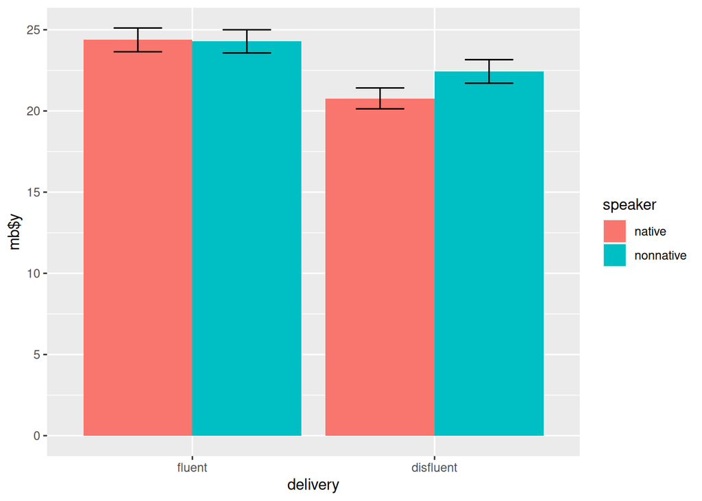

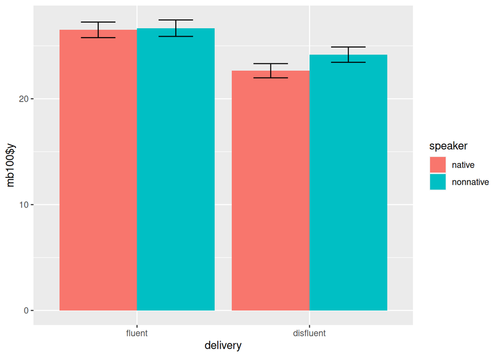

```r
df_plot <- df_ready |> group_by(delivery,speaker) |> summarise(mb=mean_se(BET),mb100=mean_se(BET100))

df_plot |> ggplot(aes(x=delivery,y=mb$y,fill=speaker)) +
  geom_bar(position="dodge",stat="identity") +
  geom_errorbar(aes(ymin=mb$ymin,ymax=mb$ymax),width=.4,position=position_dodge(.9))
df_plot |> ggplot(aes(x=delivery,y=mb100$y,fill=speaker)) +
  geom_bar(position="dodge",stat="identity") +
  geom_errorbar(aes(ymin=mb100$ymin,ymax=mb100$ymax),width=.4,position=position_dodge(.9))
```

Perhaps violin plots might make the distributions a bit clearer:

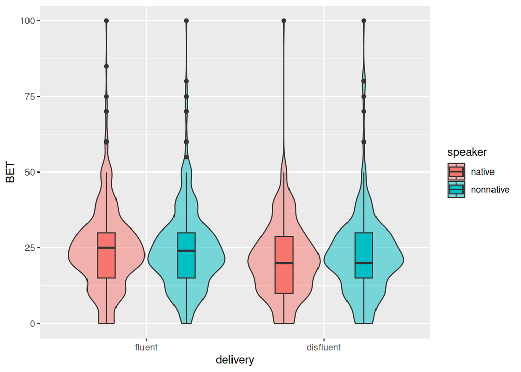

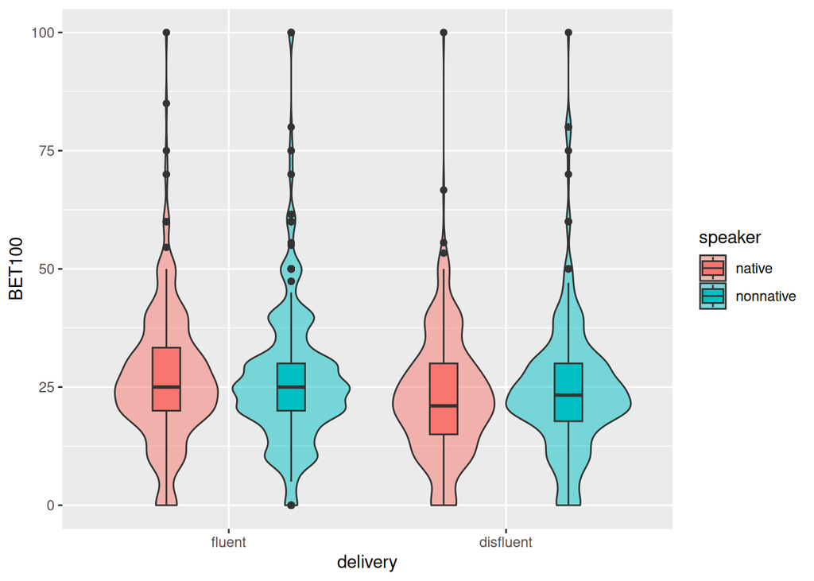

```r
df_ready |> ggplot(aes(x=delivery,y=BET,fill=speaker)) +
  geom_violin(alpha=.5) +
  geom_boxplot(width=.2,position=position_dodge(.9))
df_ready |> ggplot(aes(x=delivery,y=BET100,fill=speaker)) +
    geom_violin(alpha=.5) +
    geom_boxplot(width=.2,position=position_dodge(.9))
```

### Analysis

Let’s fit the maximal possible model to the data:

```r
modB <- buildmer(
  BET ~ delivery * speaker +
    (delivery * speaker | ppt) +
    (delivery * speaker | horse),
  buildmerControl=buildmerControl(direction='order',
    args=list(control=lme4::lmerControl(optimizer='bobyqa'))),
  data = df_ready
)
```

OK, so the maximal converging model is **BET ~ 1 + delivery + speaker + delivery:speaker + (1 | horse)**. Coefficents are shown below.

```r
library(gtsummary)
tbl_regression(modB@model,intercept=TRUE)
```

| **Characteristic** | **Beta** | **95% CI**<sup>1</sup> | **p-value** |
| --- | --- | --- | --- |
| (Intercept) | 24 | 17, 31 | 0.001 |
| delivery |  |  |  |
| delivery1 | -0.63 | -0.94, -0.32 | <0.001 |
| speaker |  |  |  |
| speaker1 | 0.01 | -0.30, 0.32 | >0.9 |
| delivery * speaker |  |  |  |
| delivery1 * speaker1 | 0.06 | -0.03, 0.15 | 0.2 |

<sup>1</sup> CI = Confidence Interval

Now let’s repeat the analysis, using the DV in which all bets are scaled to a total of 100.

```r
modB1 <- buildmer(
  BET100 ~ delivery * speaker +
    (delivery * speaker | ppt) +
    (delivery * speaker | horse),
  buildmerControl=buildmerControl(direction='order',
    args=list(control=lme4::lmerControl(optimizer='bobyqa'))),
  data = df_ready
)
```

The maximal converging model is **BET100 ~ 1 + delivery + speaker + delivery:speaker + (1 + delivery | horse)**. Coefficients:

```r
tbl_regression(modB1@model,intercept=TRUE)
```

| **Characteristic** | **Beta** | **95% CI**<sup>1</sup> | **p-value** |
| --- | --- | --- | --- |
| (Intercept) | 26 | 18, 34 | 0.002 |
| delivery |  |  |  |
| delivery1 | -0.68 | -1.1, -0.27 | 0.005 |
| speaker |  |  |  |
| speaker1 | 0.05 | -0.27, 0.37 | 0.8 |
| delivery * speaker |  |  |  |
| delivery1 * speaker1 | 0.05 | -0.05, 0.14 | 0.3 |

<sup>1</sup> CI = Confidence Interval

That’s as far as I got, but it seems to confirm Espe’s original findings. Perhaps the violin plots above give some clues as to why there is no interaction?